# ECo 602 Final Project

Emily Piersiak

11/27/2020

# Introduction

For the Final Project in ECo 602, we were tasked with creating an RMarkdown script that contains information on how to perform much of what we learned throughout the semester. This script goes through the processes of using basic functions in R, as well as showing how to perform numerical and graphical exploration, and has an example of data analysis using the delomys dataset.

# Part 1: The Basics of R

# Data Structure Functions

In this course, we focused on a few particular functions to create and describe data structures. They include c(), data.frame(), matrix(), length(), nrow(), ncol(), and dim().

## `Vector`

The function `c()` *combines* or *concatenates* its arguments into a vector (a 1-dimensional data structure consisting of 1 or more elements).

- All of the elements must be of the same *type*.
  - I can’t combine character and numeric types in the same call to `c()`

Here’s two examples using numeric and character data types:

```r
# Create a vector of numbers:
num_vec  = c(1, 4, 8, 9, 13)

# Create a vector of characters:
char_vec = c("a", "fish", "data is cool")
```

I can show the contents of a vector by typing the name of the vector, or using the `print()` function.

```r
# Typing the name of the vector into the console prints the contents
num_vec
```

```
## [1]  1  4  8  9 13
```

```r
# The print() function accomplishes the same task:
print(char_vec)
```

```
## [1] "a"            "fish"         "data is cool"
```

## `Data Frame`

The function `data.frame()` creates something called a data frame, or a group of variables. This is useful to use when you import data into R for analysis.

```r
# Create a data frame with three columns:
data_frame1  = data.frame(1, 2, 3)
```

Data frames are created when the function `read.csv()` is used to bring a csv document into R

## `Matrix`

The function `matrix()` creates a matrix from the input set of values.

```r
# Create a matrix of the list "list" with 3 rows and 3 columns:
list = c(1, 2, 3)
matrix(data = list, nrow = 3, ncol = 3, byrow = TRUE)
```

```
##      [,1] [,2] [,3]
## [1,]    1    2    3
## [2,]    1    2    3
## [3,]    1    2    3
```

The ‘nrow’ argument defines the number of rows present, while ‘ncol’ defines the number of columns present. If the ‘byrow’ argument is TRUE, the matrix fills by rows. If it is FALSE, then the matrix fills by columns.

```r
# Create a matrix where the byrow argument is FALSE
matrix(data = list, nrow = 3, ncol = 3, byrow = FALSE)
```

```
##      [,1] [,2] [,3]
## [1,]    1    1    1
## [2,]    2    2    2
## [3,]    3    3    3
```

```r
# Create a matrix where the byrow argument is TRUE
matrix(data = list, nrow = 3, ncol = 3, byrow = TRUE)
```

```
##      [,1] [,2] [,3]
## [1,]    1    2    3
## [2,]    1    2    3
## [3,]    1    2    3
```

## `Length`

The `length()` function can be used to find out the length of a vector, list, factor, or other R object with a defined method

```r
# Find the length of "length_list":
length_list = c(1, 2, 3, 4, 5, 6, 7, 8, 'a', 'b')
length(length_list)
```

```
## [1] 10
```

## `Number of Rows`

The function `nrow()` can be used to find out how many rows are present in the datset.

```r
# Find the number of rows in R's base dataset "cars"
nrow(cars)
```

```
## [1] 50
```

## `Number of Columns`

The function `ncol()` can be used to find out how many columns are present in the dataset.

```r
# Find the number of rows in R's base dataset "cars"
ncol(cars)
```

```
## [1] 2
```

## `Dimensions`

The function `dim()` can be used to find the dimension of an object. The first part of the result represents rows and the second part represents columns.

```r
# Find the dimensions of R's base dataset "cars"
dim(cars)
```

```
## [1] 50  2
```

# Subsetting Operators and Functions

When performing analyses, you don’t always need every piece of data in the entire dataset. This is where subsetting becomes helpful: it allows you to selet particular parts of the dataset and analyze those specific parts.

## `Single Brackets`

Single brackets allow you to select certain values within a vector.

```r
# Create a vector
singlebracket_vector = c(1:10)

# Select the entire vector
singlebracket_vector[]
```

```
##  [1]  1  2  3  4  5  6  7  8  9 10
```

```r
# Select the third value in the vector
singlebracket_vector[3]
```

```
## [1] 3
```

```r
# Select the values in positions 1 through 5 in the vector
singlebracket_vector[1:5]
```

```
## [1] 1 2 3 4 5
```

```r
# Select every value except for the 9th value
singlebracket_vector[-9]
```

```
## [1]  1  2  3  4  5  6  7  8 10
```

```r
# Select the values that are less than 5
singlebracket_vector[singlebracket_vector < 5]
```

```
## [1] 1 2 3 4
```

## `Dollar Sign`

The dollar sign subsetting operator allows you to select a particular column within a data frame.

```r
# Subset the Petal.Length column from the iris dataframe
iris$Petal.Length
```

```
##   [1] 1.4 1.4 1.3 1.5 1.4 1.7 1.4 1.5 1.4 1.5 1.5 1.6 1.4 1.1 1.2 1.5 1.3 1.4
##  [19] 1.7 1.5 1.7 1.5 1.0 1.7 1.9 1.6 1.6 1.5 1.4 1.6 1.6 1.5 1.5 1.4 1.5 1.2
##  [37] 1.3 1.4 1.3 1.5 1.3 1.3 1.3 1.6 1.9 1.4 1.6 1.4 1.5 1.4 4.7 4.5 4.9 4.0
##  [55] 4.6 4.5 4.7 3.3 4.6 3.9 3.5 4.2 4.0 4.7 3.6 4.4 4.5 4.1 4.5 3.9 4.8 4.0
##  [73] 4.9 4.7 4.3 4.4 4.8 5.0 4.5 3.5 3.8 3.7 3.9 5.1 4.5 4.5 4.7 4.4 4.1 4.0
##  [91] 4.4 4.6 4.0 3.3 4.2 4.2 4.2 4.3 3.0 4.1 6.0 5.1 5.9 5.6 5.8 6.6 4.5 6.3
## [109] 5.8 6.1 5.1 5.3 5.5 5.0 5.1 5.3 5.5 6.7 6.9 5.0 5.7 4.9 6.7 4.9 5.7 6.0
## [127] 4.8 4.9 5.6 5.8 6.1 6.4 5.6 5.1 5.6 6.1 5.6 5.5 4.8 5.4 5.6 5.1 5.1 5.9
## [145] 5.7 5.2 5.0 5.2 5.4 5.1
```

## `Subset`

The `subset()` function outputs a subset of a vector, matrix, or data frame. The first argument is the object to be subsetted from, and the second argument is what is to be subsetted.

```r
# Subset the rows containing information about sepals with length less than 5 from the iris dataset
subset(iris, Sepal.Length < 5)
```

```
##     Sepal.Length Sepal.Width Petal.Length Petal.Width    Species
## 2            4.9         3.0          1.4         0.2     setosa
## 3            4.7         3.2          1.3         0.2     setosa
## 4            4.6         3.1          1.5         0.2     setosa
## 7            4.6         3.4          1.4         0.3     setosa
## 9            4.4         2.9          1.4         0.2     setosa
## 10           4.9         3.1          1.5         0.1     setosa
## 12           4.8         3.4          1.6         0.2     setosa
## 13           4.8         3.0          1.4         0.1     setosa
## 14           4.3         3.0          1.1         0.1     setosa
## 23           4.6         3.6          1.0         0.2     setosa
## 25           4.8         3.4          1.9         0.2     setosa
## 30           4.7         3.2          1.6         0.2     setosa
## 31           4.8         3.1          1.6         0.2     setosa
## 35           4.9         3.1          1.5         0.2     setosa
## 38           4.9         3.6          1.4         0.1     setosa
## 39           4.4         3.0          1.3         0.2     setosa
## 42           4.5         2.3          1.3         0.3     setosa
## 43           4.4         3.2          1.3         0.2     setosa
## 46           4.8         3.0          1.4         0.3     setosa
## 48           4.6         3.2          1.4         0.2     setosa
## 58           4.9         2.4          3.3         1.0 versicolor
## 107          4.9         2.5          4.5         1.7  virginica
```

```r
# Subset the rows containing information about sepals with length less than 5  and width greater than 3 from the iris dataset
subset(iris, Sepal.Length < 5 & Sepal.Width > 3)
```

```
##    Sepal.Length Sepal.Width Petal.Length Petal.Width Species
## 3           4.7         3.2          1.3         0.2  setosa
## 4           4.6         3.1          1.5         0.2  setosa
## 7           4.6         3.4          1.4         0.3  setosa
## 10          4.9         3.1          1.5         0.1  setosa
## 12          4.8         3.4          1.6         0.2  setosa
## 23          4.6         3.6          1.0         0.2  setosa
## 25          4.8         3.4          1.9         0.2  setosa
## 30          4.7         3.2          1.6         0.2  setosa
## 31          4.8         3.1          1.6         0.2  setosa
## 35          4.9         3.1          1.5         0.2  setosa
## 38          4.9         3.6          1.4         0.1  setosa
## 43          4.4         3.2          1.3         0.2  setosa
## 48          4.6         3.2          1.4         0.2  setosa
```

# Numerical Data Exploration

Throughout the semester, we learned a few different ways to explore data numerically. The include summary(), mean(), and sd().

## `Summary`

The function `summary()` is used to show a concise summary of an object such as a vector, list, matrix, or other object. The given summary output depends on the input object.

```r
# Show a summary of the list that is created below.
summary_list = c(1, 2, 3, 4, 5, 6, 7, 8, 'a', 'b')
summary(summary_list)
```

```
##    Length     Class      Mode
##        10 character character
```

```r
# Show a summary of the matrix that is created below.
summary_matrix = (matrix(data = list, nrow = 3, ncol = 3, byrow = TRUE))
summary(summary_matrix)
```

```
##        V1          V2          V3
##  Min.   :1   Min.   :2   Min.   :3
##  1st Qu.:1   1st Qu.:2   1st Qu.:3
##  Median :1   Median :2   Median :3
##  Mean   :1   Mean   :2   Mean   :3
##  3rd Qu.:1   3rd Qu.:2   3rd Qu.:3
##  Max.   :1   Max.   :2   Max.   :3
```

```r
# Show a summary of the vector that is created below.
summary_vector = c(4, 7, 22, 57)
summary(summary_vector)
```

```
##    Min. 1st Qu.  Median    Mean 3rd Qu.    Max.
##    4.00    6.25   14.50   22.50   30.75   57.00
```

```r
# Show a summary of the linear model that is created below.
summary_lm = lm(data = cars)
summary(summary_lm)
```

```
##
## Call:
## lm(data = cars)
##
## Residuals:
##     Min      1Q  Median      3Q     Max
## -7.5293 -2.1550  0.3615  2.4377  6.4179
##
## Coefficients:
##             Estimate Std. Error t value Pr(>|t|)
## (Intercept)  8.28391    0.87438   9.474 1.44e-12 ***
## dist         0.16557    0.01749   9.464 1.49e-12 ***
## ---
## Signif. codes:  0 '***' 0.001 '**' 0.01 '*' 0.05 '.' 0.1 ' ' 1
##
## Residual standard error: 3.156 on 48 degrees of freedom
## Multiple R-squared:  0.6511, Adjusted R-squared:  0.6438
## F-statistic: 89.57 on 1 and 48 DF,  p-value: 1.49e-12
```

## `Mean`

The function `mean()` is used to find the arithmetic mean of a particular object.

```r
# Find the mean of the following vector:
mean_vector = c(4, 7, 22, 57)
mean(mean_vector)
```

```
## [1] 22.5
```

## `Standard Deviation`

The function `sd()` is used to find the standard deviation of a particular object.

```r
# Find the standard deviation of the following vector:
sd_vector = c(4, 7, 22, 57)
sd(sd_vector)
```

```
## [1] 24.31049
```

# Graphical Data Exploration

We also learned a variety of methods for graphical data exploration. The `par()` function can be used to display a number of graphs on the same panel. The funtions `plot()`, `hist()`, and `boxplot()` all create different graphs of the data.

## `Parameters`

The `par()` function allows you to set the graphical parameters. Using the `mfrow=` argument, you can create an image that shows a number of graphs side by side.

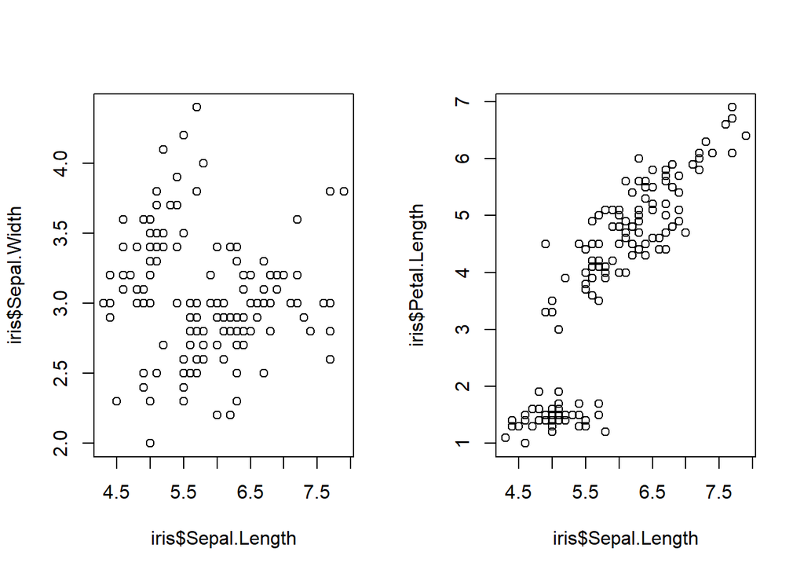

```r
# Create a display of two graphs side by side
par(mfrow = c(1, 2))
plot(iris$Sepal.Length, iris$Sepal.Width)
plot(iris$Sepal.Length, iris$Petal.Length)
```

## `Scatterplot`

Use the `plot()` function to create a scatterplot of two numerical datasets.

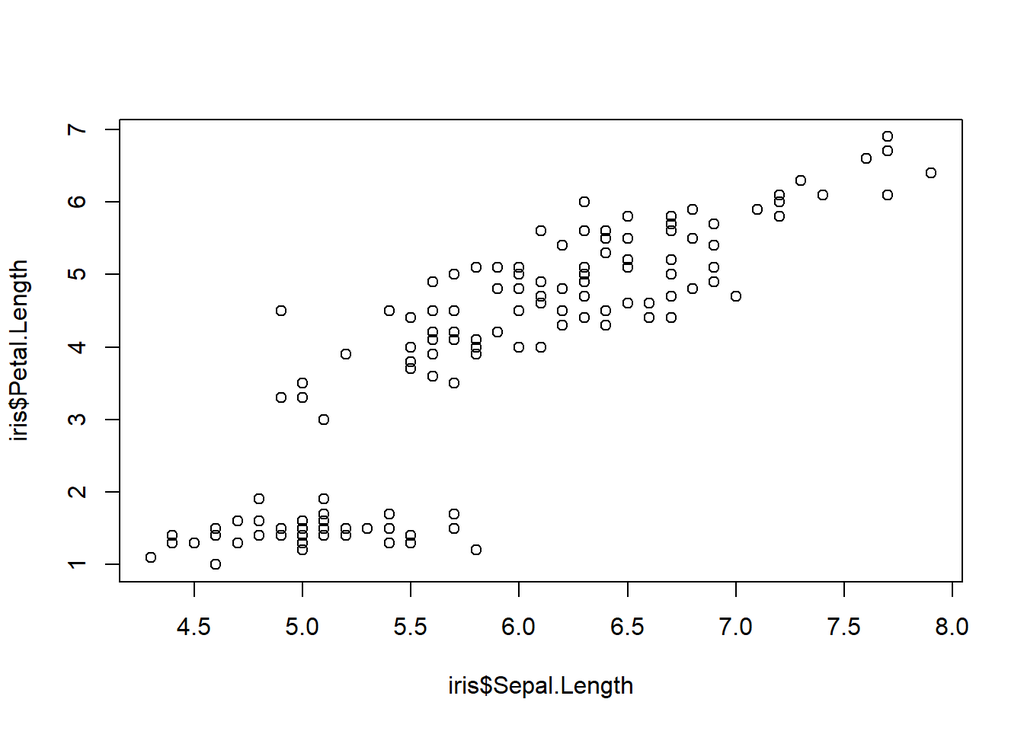

```r
# Make a scatterplot of sepal length by petal length
plot(iris$Sepal.Length, iris$Petal.Length)
```

You can use a variety of arguments to modify your plot and make it easier to read, including `col=`, `pch=`, `cex=`, `main=`, `xlab=`, `ylab=`, `xlim=`, and `ylim=`.

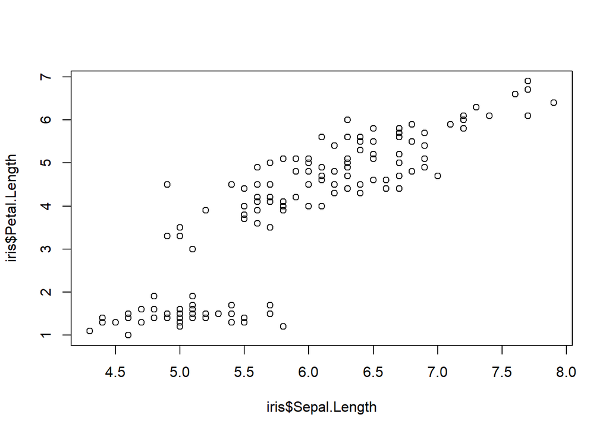

```r
# Make a scatterplot of sepal length by petal length
plot(iris$Sepal.Length, iris$Petal.Length)
```

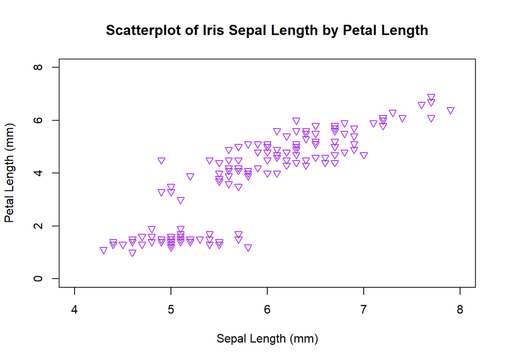

```r
# Give the following:
  # a meaningful title with "main="
  # x and y axis lables with "xlab" and "ylab"
  # limits to the x and y axes with "xlim" and "ylim"
  # color with "col"
  # a nice point shape with "pch"
  # appropriately scaled text and symbols
plot(iris$Sepal.Length, iris$Petal.Length,
     main = "Scatterplot of Iris Sepal Length by Petal Length",
     xlab = "Sepal Length (mm)",
     ylab = "Petal Length (mm)",
     xlim = c(4,8),
     ylim = c(0,8),
     col = "purple",
     pch = 6,
     cex = 1)
```

- Other color arguments are as follows:
  - col.axis (for changing the color of axis annotation)
  - col.lab (for changing the color of the x and y labels)
  - col.main (for changing the color of the main title)
  - col.sub (for changing the color of the subtitles),
  - fg (for changing the color of the foreground - axes and boxes)
  - bg (for changing the color of the plot background).

## `Histogram`

Use the `hist()` function to create a histogram of a particular set of data. Change the number of breaks in the histogram with the `breaks` argument.

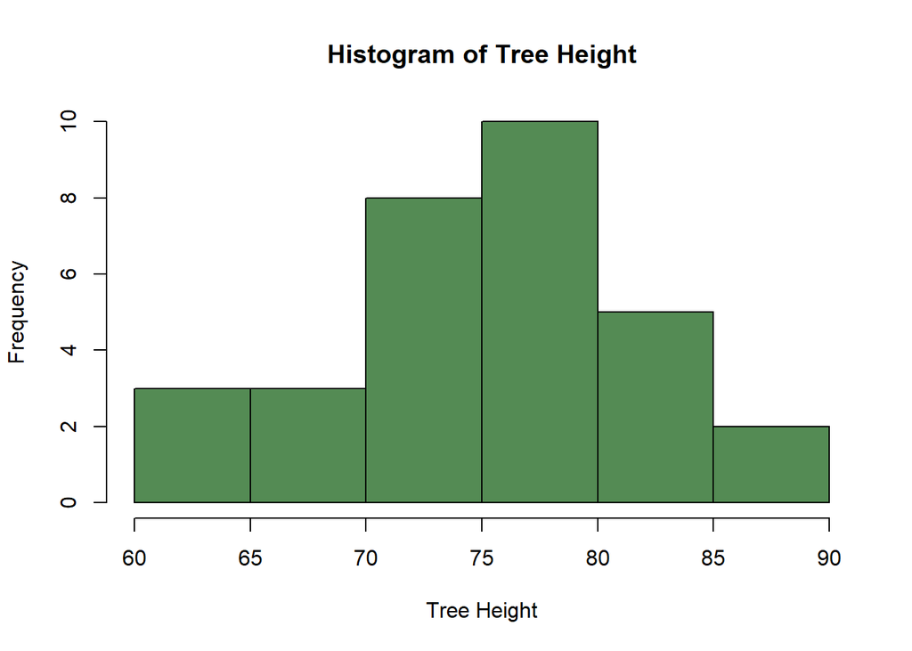

```r
# Create a histogram of tree height using the trees dataset with default breaks
hist(trees$Height,
     main = "Histogram of Tree Height",
     xlab = "Tree Height",
     ylab = "Frequency",
     col = "palegreen4")
```

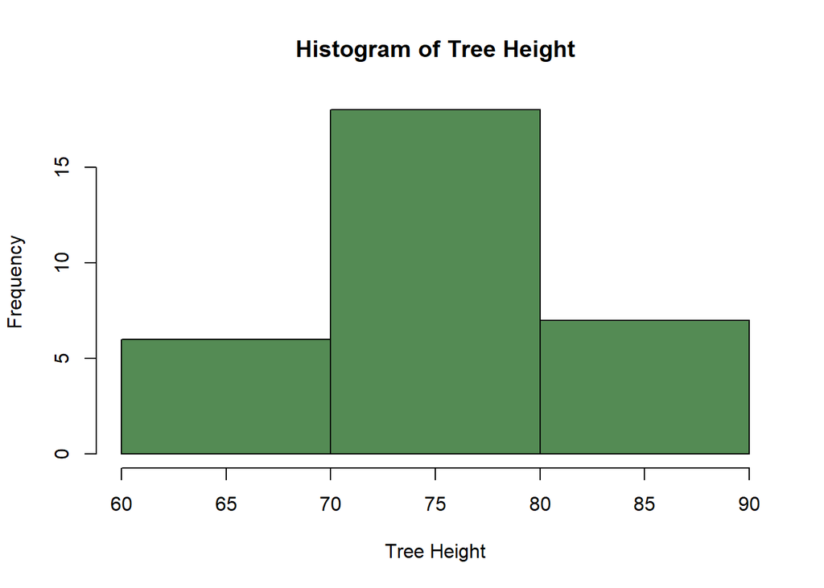

```r
# Create a histogram  of tree height with custom breaks
# Note that this isn't a great choice for break placements.
hist(trees$Height,
     main = "Histogram of Tree Height",
     xlab = "Tree Height",
     ylab = "Frequency",
     breaks = c(60,70,80,90),
     col = "palegreen4")
```

## `Boxplot`

Use `boxplot()` to create a box and whisker plot of a dataset.

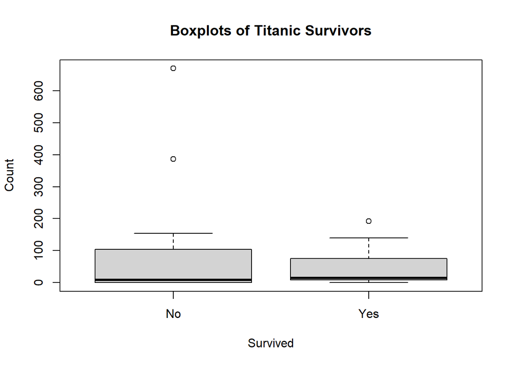

```r
# Create a standard boxplot of survivors from the Titanic Shipwreck.
boxplot(Freq~Survived, data = Titanic,
        main = "Boxplots of Titanic Survivors",
        ylab = "Count")
```

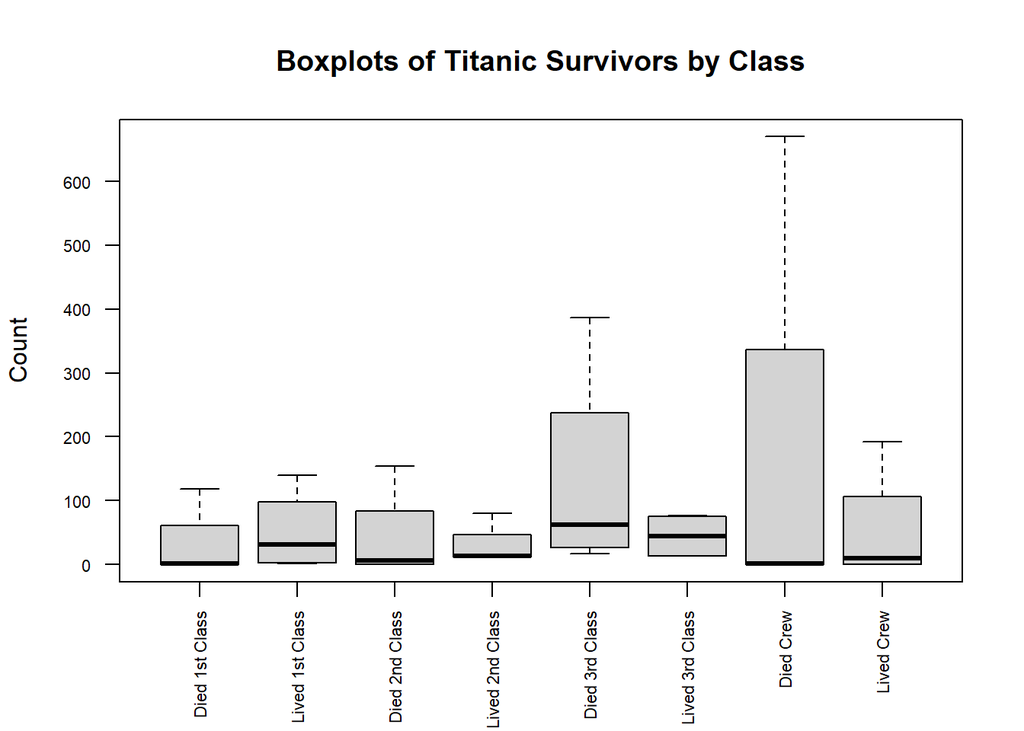

```r
# Create a conditional boxplot of survivors on sex and class from the Titanic shipwerk using the Titanic dataset
boxplot(Freq ~ Survived*Class, data = Titanic,
        main = "Boxplots of Titanic Survivors by Class",
        ylab = "Count",
        xlab = NULL,
        names = c("Died 1st Class", "Lived 1st Class", "Died 2nd Class", "Lived 2nd Class",
        "Died 3rd Class", "Lived 3rd Class", "Died Crew", "Lived Crew"),
        las = 2,
        cex.axis = .7
)
```

```r
 # Note: the las argument changes the orientation of the axis sub-labels
```

# Distribution Functions

## `Probability Density Function`

The `dnorm()` function is the probability density function, which is used for continuous distributions. With `dnorm()`, you can answer the question “how likely is the following value in a distribution with a particular mean and standard deviation?”

```r
# Find the probability of the value 1.2 showing up in a distribution with a mean of 5 and a standard deviation of 2.
dnorm(1.2, 5, 2)
```

```
## [1] 0.03280791
```

## `Cumulative Density Function`

The `pnorm()` function is the cumulative density function, which is used with continuous distributions. With `pnorm()`, you can answer the question “how likely is it that I will choose a value of x or less from a distribution with a particular mean and standard deviation?”

```r
# Find the probability of picking a value of 3 or less in a distribution with a mean of 5 and a standard deviation of 2.
pnorm(3, 5, 2)
```

```
## [1] 0.1586553
```

You can find the probability of picking a value within a particular range by subtracting one probability from another using the cumulative density function.

```r
# Find the probability of picking a value between 3 and 4 in a distribution with a mean of 5 and a standard deviation of 2.
pnorm(4, 5, 2) - pnorm(3, 5, 2)
```

```
## [1] 0.1498823
```

You can find the probability of choosing a value of x or greater by subtracting the probability of choosing that value or less from 1.

```r
# Find the probability of picking a value of 3 or greater in a distribution with a mean of 5 and a standard deviation of 2.
1 - pnorm(3, 5, 2)
```

```
## [1] 0.8413447
```

## `Quantile Function (qnorm)`

With the `qnorm()` function, also known as the quantile function, you can find the value of a particular percentile of a continuous distribution. For example, you could find the value of the 20th percentile in a distribution with a mean of x and a standard deviation of y.

```r
# Find the value of the 30th percentile in a distribution with a mean of 5 and a standard deviation of 2.
qnorm(.3, 5, 2)
```

```
## [1] 3.951199
```

## `Probability Mass Function`

- The probability mass function is used to find the probability of observing an exact value in a binomial distribution. The function `dbinom()` has the following common arguments:
  - x, or a vector of quantities
  - size, or the number of trials
  - prob, or the probability

```r
# Find the probability of observing a count of exactly three successes in a binomial distribution where the number of trials is 4 and the probability of success is 0.75.
dbinom(3, 4, 0.75)
```

```
## [1] 0.421875
```

The cumulative mass function is used to find the probability of observing an exact value or less in a binomial distribution. The function `pbinom()` has the following common arguments: - q, or a vector of quantities - size, or the number of trials - prob, or the probability

```r
# Find the probability of observing a count of three successes or fewer in a binomial distribution where the number of trials is 4 and the probability of success is 0.75.
pbinom(3, 4, 0.75)
```

```
## [1] 0.6835937
```

## `Quantile Function (qbinom)`

- The quantile function is used to find the value at a particular percentile in a binomial distribution. The function `qbinom()` has the following common arguments:
  - p, or the percentile
  - size, or the number of trials
  - prob, or the probability

```r
# Find the value of the 40th percentile in a binomial distribution with a size of 4 and a probability of success of 0.75
qbinom(.4, 4, 0.75)
```

```
## [1] 3
```

# Other Functions

These functions are incredibly important to know if you want to use R for analysis. The `library()` and `require()` functions load packages and attach any other necessary packages.

## `library()`

Add `library()` to the top of every script as a good habit to tell R that you are going to use some base functions. You can also use it to load packages for use in the analysis.

```r
# Load the base R library
library()

# Load the tidyverse package
library("tidyverse")
# The tidyverse is home to ggplot2 and dplyr (among many other packages), both very helpful tools for statistical analyses.
```

## `require()`

Use `require()` to tell R that you are going to use some data that you have from a specific location, or to load a specific package.

```r
# Require the tidyverse package
require("tidyverse")
# Tell R that you want to use data from "here", a specified location in your project folder
require(here)
```

## `read.csv()`

Use this function to read in data and create a data frame from a .csv file.

```r
# Read in the delomys dataset. First, the working directory must be set to a location where the file of interest exists.
setwd("D:/umass/eco_602_2020/ECo_602_2020/data")
read.csv('delomys.csv')
```

[output not shown]

[output cut: 3157 more lines]

# Part 2: Data Anaylsis

## `Numerical Exploration`

### Display Summary Statistics

Use the summary function to see some summary statistics on body mass and body length from the delomys dataset.

```r
# Read in the delomys dataset. First, the working directory must be set to a location where the file of interest exists.
setwd("D:/umass/eco_602_2020/ECo_602_2020/data")
dat_delomys = read.csv('delomys.csv')

# See the summary statistics from delomys$body_length
summary(dat_delomys$body_length)
```

```
##    Min. 1st Qu.  Median    Mean 3rd Qu.    Max.
##    49.0   106.0   116.0   114.7   124.0   265.0
```

```r
# See the summary statistics from delomys$body_mass
summary(dat_delomys$body_mass)
```

```
##    Min. 1st Qu.  Median    Mean 3rd Qu.    Max.
##    5.00   35.00   43.00   44.06   54.00  105.00
```

### Perform a Test of Normality

```r
# Perform a Shapiro test to determine the normality of body length in the dat_delomys dataset
shapiro.test(dat_delomys$body_length)
```

```
##
##  Shapiro-Wilk normality test
##
## data:  dat_delomys$body_length
## W = 0.87609, p-value < 2.2e-16
```

```r
# Perform a Shapiro test to determine the normality of body mass in the dat_delomys dataset
shapiro.test(dat_delomys$body_mass)
```

```
##
##  Shapiro-Wilk normality test
##
## data:  dat_delomys$body_mass
## W = 0.99506, p-value = 4.33e-05
```

## `Graphical Exploration`

Use a variety of graphs to visually explore the data.

### Scatterplot

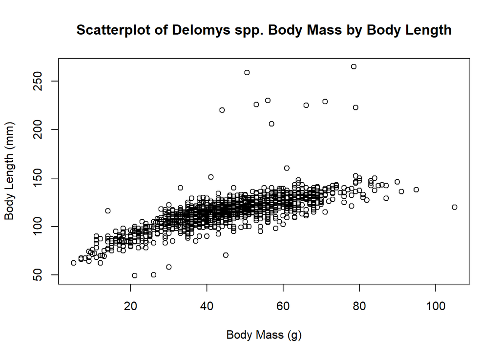

```r
# Create a scatterplot of delomys body mass by body length
require(dat_delomys)
plot(dat_delomys$body_mass, dat_delomys$body_length,
     main = "Scatterplot of Delomys spp. Body Mass by Body Length",
     xlab = "Body Mass (g)",
     ylab = "Body Length (mm)")
```

Delomys spp. body mass and length have a positively correlated relationship, meaning that as body mass increases, body length also increases. This relationship is generally linear with a slight curve, excluding outliers.

### Histograms

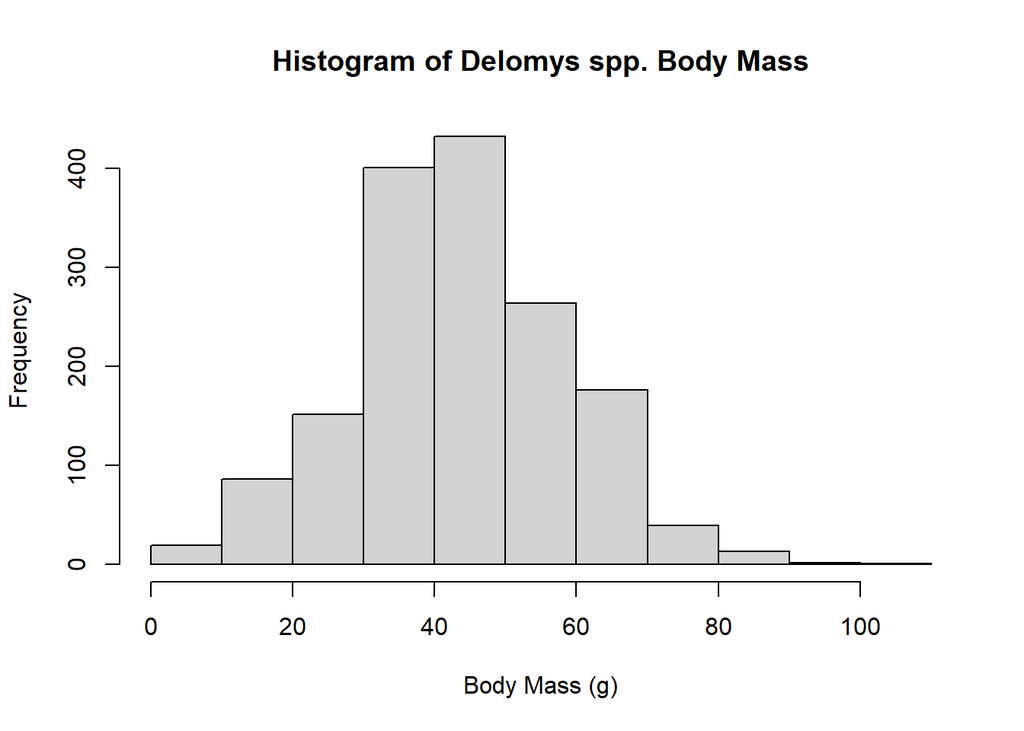

```r
# Create a histogram of delomys body mass
require(dat_delomys)
hist(dat_delomys$body_mass,
     main = "Histogram of Delomys spp. Body Mass",
     xlab = "Body Mass (g)",
     ylab = "Frequency")
```

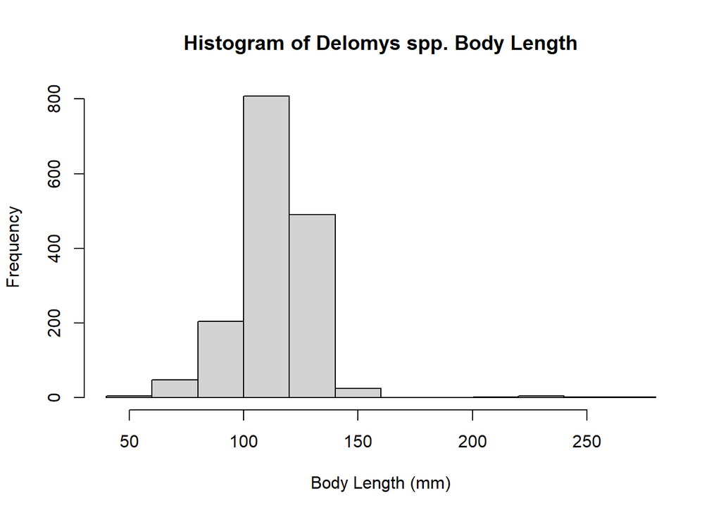

```r
# Create a histogram of delomys body length
require(dat_delomys)
hist(dat_delomys$body_length,
     main = "Histogram of Delomys spp. Body Length",
     xlab = "Body Length (mm)",
     ylab = "Frequency")
```

### Conditional Boxplots

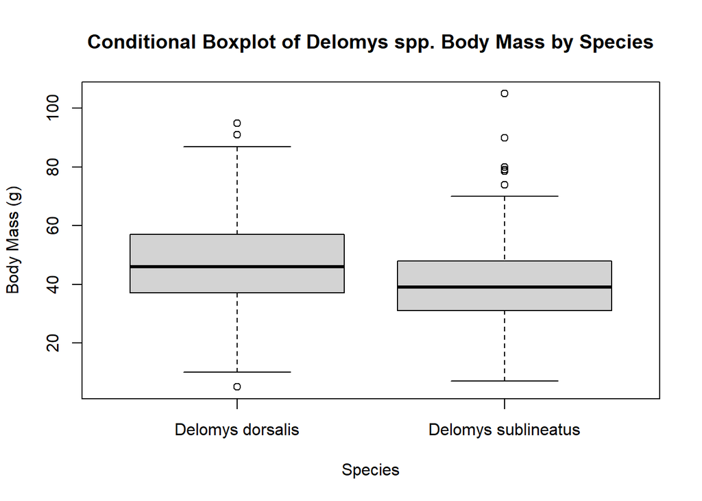

```r
# Create a conditional boxplot of body mass, conditioned on species
require(dat_delomys)
boxplot(body_mass~binomial, data = dat_delomys,
        main = "Conditional Boxplot of Delomys spp. Body Mass by Species",
        ylab = "Body Mass (g)",
        xlab = "Species")
```

With a visual assessment of this conditional boxplot, we can see that the mean weight of D. sublineatus is lower than the mean weight of D. dorsalis. We cannot make any statistical determinations with a visual assessment, but it can lead us to perform more statistical tests to see if the mean weight of D. sublineatus is truly lower than the mean weight of D. dorsalis.

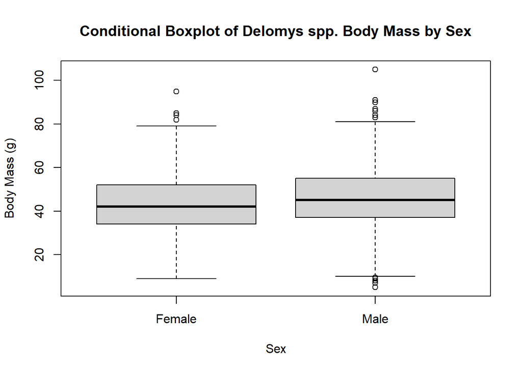

```r
# Create a conditional boxplot of body mass, conditioned on sex
require(dat_delomys)
boxplot(body_mass~sex, data = dat_delomys,
        main = "Conditional Boxplot of Delomys spp. Body Mass by Sex",
        ylab = "Body Mass (g)",
        xlab = "Sex",
        names = c("Female", "Male"))
```

The weight of male Delomys spp. organisms seems to be slightly higher than the females. Again, we cannot make any statistical inferences from a visual assessment, but we can move on to perform a t-test to compare the mean weights of male and female Delomys organisms.

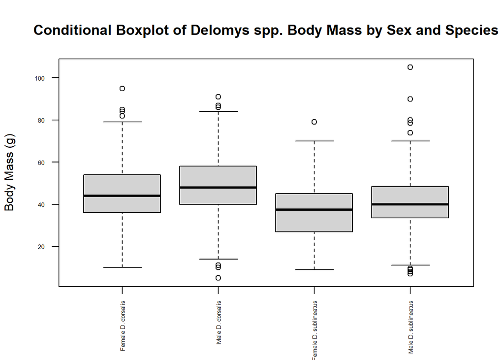

```r
# Create a conditional boxplot of body mass, conditioned on sex and species
require(dat_delomys)
boxplot(body_mass~sex*binomial, data = dat_delomys,
        main = "Conditional Boxplot of Delomys spp. Body Mass by Sex and Species",
        las = 2,
        xlab= NULL,
        ylab = "Body Mass (g)",
        cex.axis = .5,
        names = c("Female D. dorsalis", "Male D. dorsalis", "Female D. sublineatus", "Male D. sublineatus"))
```

## `Model Building and Diagnostics`

### Linear Models

```r
require(dat_delomys)
# Create a linear model to predict body length as a function of body mass
fit1 = lm(body_length~body_mass, data = dat_delomys)

# Create a linear model to predict body mass as a function of sex
fit2 = lm(body_mass~sex, data = dat_delomys)

# Create a linear model to predict body mass as a function of species
fit3 = lm(body_mass~binomial, data = dat_delomys)

# Create an additive linear model to predict body mass as a function of species AND sex
fit4 = lm(body_mass~sex + binomial, data = dat_delomys)

# Create a factorial linear model to predict body mass as a function of species AND sex
fit5 = lm(body_mass~sex*binomial, data = dat_delomys)
```

### Histograms and Graphical Exploration

Plot histograms of the residuals from each of the five models.

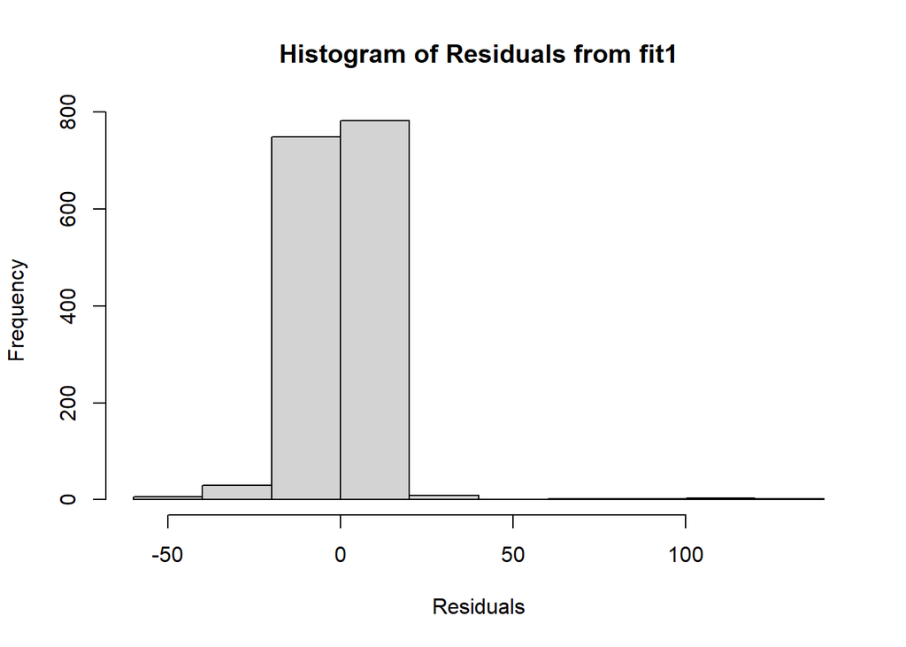

```r
# Create a histogram of the residuals from the five fits

# fit1
hist(residuals(fit1),
     main = "Histogram of Residuals from fit1",
     xlab = "Residuals",)
```

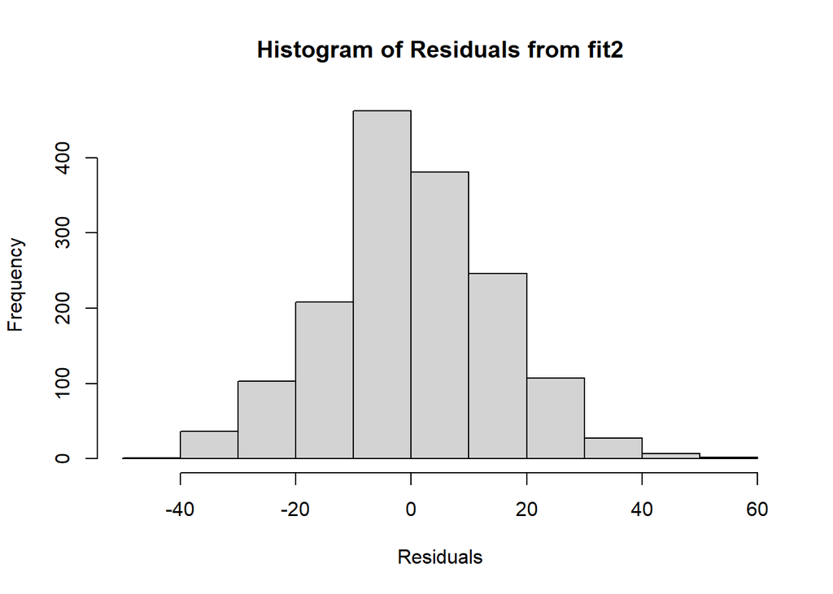

```r
# fit2
hist(residuals(fit2),
     main = "Histogram of Residuals from fit2",
     xlab = "Residuals",)
```

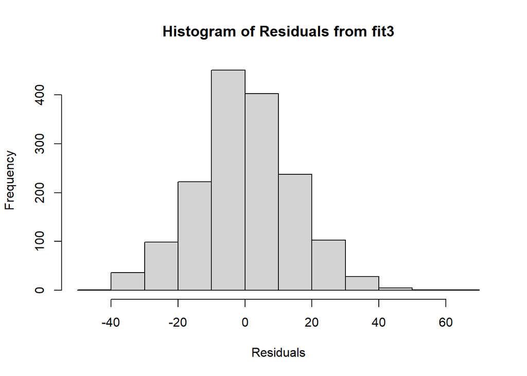

```r
# fit3
hist(residuals(fit3),
     main = "Histogram of Residuals from fit3",
     xlab = "Residuals",)
```

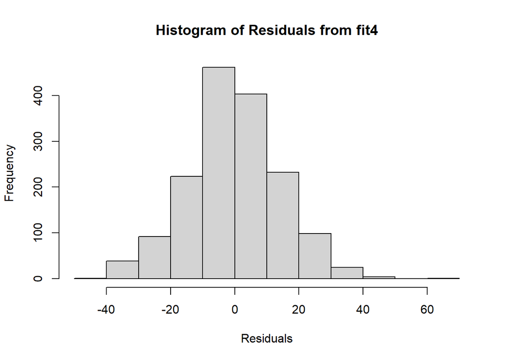

```r
# fit4
hist(residuals(fit4),
     main = "Histogram of Residuals from fit4",
     xlab = "Residuals",)
```

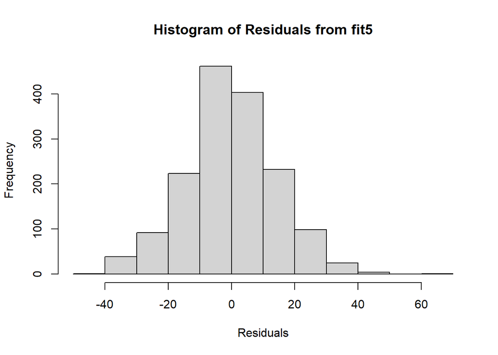

```r
# fit5
hist(residuals(fit5),
     main = "Histogram of Residuals from fit5",
     xlab = "Residuals",)
```

### Using the Shapiro Test

Test the normality of the residuals from each of the 5 models.

```r
# Use a Shapiro test to determine normality of distribution of residuals from the five fits

# fit1
shapiro.test(fit1$residuals)
```

```
##
##  Shapiro-Wilk normality test
##
## data:  fit1$residuals
## W = 0.73462, p-value < 2.2e-16
```

```r
# fit2
shapiro.test(fit2$residuals)
```

```
##
##  Shapiro-Wilk normality test
##
## data:  fit2$residuals
## W = 0.99563, p-value = 0.0001541
```

```r
# fit3
shapiro.test(fit3$residuals)
```

```
##
##  Shapiro-Wilk normality test
##
## data:  fit3$residuals
## W = 0.99535, p-value = 8.103e-05
```

```r
# fit4
shapiro.test(fit4$residuals)
```

```
##
##  Shapiro-Wilk normality test
##
## data:  fit4$residuals
## W = 0.99525, p-value = 6.805e-05
```

```r
# fit5
shapiro.test(fit5$residuals)
```

```
##
##  Shapiro-Wilk normality test
##
## data:  fit5$residuals
## W = 0.99526, p-value = 6.816e-05
```

## `Model Interpretation`

### Body Length

```r
# Print the model coefficient table for the relationship between body mass and body length
knitr::kable(coef(summary(fit1)), digits = c(3))
```

|  | Estimate | Std. Error | t value | Pr(>\|t\|) |
| --- | --- | --- | --- | --- |
| (Intercept) | 76.125 | 0.916 | 83.123 | 0 |
| body_mass | 0.875 | 0.020 | 44.463 | 0 |

### Body Mass: Model Coefficients

Print the model coeffcient tables for the second and third models:

```r
# Print the model coefficient table for the relationship between body mass and sex
knitr::kable(coef(summary(fit2)), digits = c(3))
```

|  | Estimate | Std. Error | t value | Pr(>\|t\|) |
| --- | --- | --- | --- | --- |
| (Intercept) | 42.711 | 0.529 | 80.756 | 0 |
| sexmale | 2.784 | 0.746 | 3.734 | 0 |

The base level for sex is female, weighing 42.711 grams. Males are heavier than females.

```r
# Print the model coefficient table for the relationship between body mass and species
knitr::kable(coef(summary(fit3)), digits = c(3))
```

|  | Estimate | Std. Error | t value | Pr(>\|t\|) |
| --- | --- | --- | --- | --- |
| (Intercept) | 46.752 | 0.45 | 103.896 | 0 |
| binomialDelomys sublineatus | -7.683 | 0.76 | -10.103 | 0 |

The base level for species (binomial) is D. dorsalis, weighing 46.752 grams. D. dorsalis weighs more than D. sublineatus.

### Body Mass: ANOVA

Print the ANOVA table for each of the body mass models:

```r
# body mass and length
knitr::kable(anova(fit1), digits = c(3))
```

|  | Df | Sum Sq | Mean Sq | F value | Pr(>F) |
| --- | --- | --- | --- | --- | --- |
| body_mass | 1 | 269388.9 | 269388.909 | 1976.957 | 0 |
| Residuals | 1583 | 215706.6 | 136.264 | NA | NA |

```r
# body mass and sex
knitr::kable(anova(fit2), digits = c(3))
```

|  | Df | Sum Sq | Mean Sq | F value | Pr(>F) |
| --- | --- | --- | --- | --- | --- |
| sex | 1 | 3061.678 | 3061.678 | 13.943 | 0 |
| Residuals | 1578 | 346507.131 | 219.586 | NA | NA |

```r
# body mass and species
knitr::kable(anova(fit3), digits = c(3))
```

|  | Df | Sum Sq | Mean Sq | F value | Pr(>F) |
| --- | --- | --- | --- | --- | --- |
| binomial | 1 | 21289.68 | 21289.680 | 102.075 | 0 |
| Residuals | 1583 | 330164.45 | 208.569 | NA | NA |

```r
# body mass and sex with species (binomial) additive
knitr::kable(anova(fit4), digits = c(3))
```

|  | Df | Sum Sq | Mean Sq | F value | Pr(>F) |
| --- | --- | --- | --- | --- | --- |
| sex | 1 | 3061.678 | 3061.678 | 14.958 | 0 |
| binomial | 1 | 23727.134 | 23727.134 | 115.923 | 0 |
| Residuals | 1577 | 322779.997 | 204.680 | NA | NA |

```r
# body mass and sex with species (binomial) factorial
knitr::kable(anova(fit5), digits = c(3))
```

|  | Df | Sum Sq | Mean Sq | F value | Pr(>F) |
| --- | --- | --- | --- | --- | --- |
| sex | 1 | 3061.678 | 3061.678 | 14.949 | 0.00 |
| binomial | 1 | 23727.134 | 23727.134 | 115.850 | 0.00 |
| sex:binomial | 1 | 0.791 | 0.791 | 0.004 | 0.95 |
| Residuals | 1576 | 322779.206 | 204.809 | NA | NA |

## `Model Comparison: Body Mass`

### AIC

Calculate the AIC for each of the body mass models.

```r
# fit2
AIC(fit2)
```

```
## [1] 13006.8
```

```r
# fit3
AIC(fit3)
```

```
## [1] 12966.36
```

```r
# fit4
AIC(fit4)
```

```
## [1] 12896.73
```

```r
# fit5
AIC(fit5)
```

```
## [1] 12898.72
```

The two models that have the lowest AIC are fit4 (the additive model with sex and species) and fit5 (the factorial model with sex and species). I would choose to continue my analysis with the additive model, because it is less complex to perform and understand, as it has a slightly lower AIC than the factorial model. The additive model has more precise results than the factorial model, which, in combination with the ease of creating and understanding, makes it the better model for my analysis.